# Social Impacts on Youth Drugs Use

Let’s clearly state our research question. We are interested in the effects of a youth’s social environment on their use of marijuana. This may involve support from parents, support from friends, teachers, and one’s overall community.

```r
library(tree)
```

```r
library(ggplot2)
library(gbm)
library(randomForest)
set.seed(1)
youth_data <- read.csv("https://raw.githubusercontent.com/JesseLoi/Youth_Drug_Use/refs/heads/main/youth_data1.csv")



# View the first few rows
head(youth_data)
```

|  | IRALCFY | IRMJFY | IRCIGFM | IRSMKLSS30N | IRALCFM | IRMJFM | IRCIGAGE | IRSMKLSSTRY | IRALCAGE | IRMJAGE | MRJFLAG | ALCFLAG | TOBFLAG | ALCYDAYS | MRJYDAYS | ALCMDAYS | MRJMDAYS | CIGMDAYS | SMKLSMDAYS | SCHFELT | TCHGJOB | AVGGRADE | STNDSCIG | STNDSMJ | STNDALC | STNDDNK | PARCHKHW | PARHLPHW | PRCHORE2 | … |
| --- | --- | --- | --- | --- | --- | --- | --- | --- | --- | --- | --- | --- | --- | --- | --- | --- | --- | --- | --- | --- | --- | --- | --- | --- | --- | --- | --- | --- | --- | --- |
| 1 | 991 | 991 | 91 | 91 | 91 | 91 | 991 | 991 | 991 | 991 | 0 | 0 | 0 | 6 | 6 | 5 | 5 | 6 | 5 | 1 | 1 | 2 | 2 | 2 | 2 | 2 | 1 | 1 | 1 | … |
| 2 | 991 | 60 | 91 | 91 | 91 | 2 | 991 | 991 | 991 | 14 | 1 | 0 | 0 | 6 | 3 | 5 | 1 | 6 | 5 | 2 | 1 | 2 | 1 | 1 | 1 | 1 | 1 | 1 | 2 | … |
| 3 | 1 | 991 | 91 | 91 | 93 | 91 | 991 | 991 | 11 | 991 | 0 | 1 | 0 | 1 | 6 | 5 | 5 | 6 | 5 | 1 | 1 | 2 | 2 | 2 | 2 | 2 | 1 | 1 | 1 | … |
| 4 | 991 | 991 | 91 | 91 | 91 | 91 | 991 | 991 | 991 | 991 | 0 | 0 | 0 | 6 | 6 | 5 | 5 | 6 | 5 | 2 | 1 | NA | 2 | 2 | 2 | 2 | 1 | 2 | 2 | … |
| 5 | 991 | 991 | 91 | 91 | 91 | 91 | 991 | 991 | 991 | 991 | 0 | 0 | 0 | 6 | 6 | 5 | 5 | 6 | 5 | 1 | 2 | 2 | 2 | 2 | 2 | 2 | 2 | 1 | 1 | … |
| 6 | 991 | 991 | 91 | 91 | 91 | 91 | 991 | 991 | 991 | 991 | 0 | 0 | 0 | 6 | 6 | 5 | 5 | 6 | 5 | 1 | 1 | 2 | 2 | 2 | 2 | 2 | 1 | 1 | 1 | … |

Let’s look at the data structure.

```r
str(youth_data)
```

```
## 'data.frame':    10561 obs. of  79 variables:
##  $ IRALCFY    : int  991 991 1 991 991 991 991 993 991 991 ...
##  $ IRMJFY     : int  991 60 991 991 991 991 991 991 991 991 ...
##  $ IRCIGFM    : num  91 91 91 91 91 91 91 91 91 91 ...
##  $ IRSMKLSS30N: int  91 91 91 91 91 91 91 91 91 91 ...
##  $ IRALCFM    : num  91 91 93 91 91 91 91 93 91 91 ...
##  $ IRMJFM     : num  91 2 91 91 91 91 91 91 91 91 ...
##  $ IRCIGAGE   : int  991 991 991 991 991 991 991 991 991 991 ...
##  $ IRSMKLSSTRY: int  991 991 991 991 991 991 991 991 991 991 ...
##  $ IRALCAGE   : int  991 991 11 991 991 991 991 12 991 991 ...
##  $ IRMJAGE    : int  991 14 991 991 991 991 991 991 991 991 ...
##  $ MRJFLAG    : int  0 1 0 0 0 0 0 0 0 0 ...
##  $ ALCFLAG    : int  0 0 1 0 0 0 0 1 0 0 ...
##  $ TOBFLAG    : int  0 0 0 0 0 0 0 0 0 0 ...
##  $ ALCYDAYS   : int  6 6 1 6 6 6 6 6 6 6 ...
```

[output cut: 65 more lines]

We have 10,000 observations. This is plenty to work with, so we can split the training and test datasets half and half.

Let’s try out binary classification. Let’s see if we can develop a model to check if we can detect the rate at which youth ever use marijuana, MRJFLAG. Let’s make a naive model that uses all traits.

Let’s use a decision tree to start, and see how ensemble techniques can be used to enhance our investigation.

Let’s split the data into training and test sets.

```r
samp<-sample(1:nrow(youth_data),nrow(youth_data)/2)

train<-youth_data[samp,]

test<-youth_data[-samp,]
```

```r
youth_data$MRJFLAG<-as.factor(youth_data$MRJFLAG)

tree.MRJFLAG<-tree(factor(MRJFLAG)~. -IRALCFY   -IRMJFY -IRCIGFM    -IRSMKLSS30N    -IRALCFM    -IRMJFM -IRCIGAGE   -IRSMKLSSTRY    -IRALCAGE   -IRMJAGE    -ALCFLAG    -TOBFLAG    -ALCYDAYS   -MRJYDAYS   -ALCMDAYS   -MRJMDAYS   -CIGMDAYS   -SMKLSMDAYS -FRDMEVR2 -FRDMJMON, train)

summary(tree.MRJFLAG)
```

```
##
## Classification tree:
## tree(formula = factor(MRJFLAG) ~ . - IRALCFY - IRMJFY - IRCIGFM -
##     IRSMKLSS30N - IRALCFM - IRMJFM - IRCIGAGE - IRSMKLSSTRY -
##     IRALCAGE - IRMJAGE - ALCFLAG - TOBFLAG - ALCYDAYS - MRJYDAYS -
##     ALCMDAYS - MRJMDAYS - CIGMDAYS - SMKLSMDAYS - FRDMEVR2 -
##     FRDMJMON, data = train)
## Variables actually used in tree construction:
## [1] "YFLMJMO" "STNDSMJ" "PRMJMO"
## Number of terminal nodes:  5
## Residual mean deviance:  0.6512 = 2679 / 4114
## Misclassification error rate: 0.1377 = 567 / 4119
```

This is a pretty good misclassification rate. Let’s try our test error rate.

```r
pred<-predict(tree.MRJFLAG, test, type="class")

table(pred, test$MRJFLAG)
```

```
##
## pred    0    1
##    0 4261  428
##    1  224  368
```

```r
(224+428)/(sum(table(pred, test$MRJFLAG)))
```

```
## [1] 0.1234615
```

It seems that we have a 87 percent accuracy rate, which is pretty good. This is even before cleaning the data. The point of this, however, was just to check.

Let’s see if we can prune our tree.

```r
cv.MRJFLAG <- cv.tree(tree.MRJFLAG, FUN = prune.misclass)
names(cv.MRJFLAG)
```

```
## [1] "size"   "dev"    "k"      "method"
```

```r
cv.MRJFLAG
```

```
## $size
## [1] 5 3 1
##
## $dev
## [1] 572 572 672
##
## $k
## [1] -Inf  0.0 52.5
##
## $method
## [1] "misclass"
##
## attr(,"class")
## [1] "prune"         "tree.sequence"
```

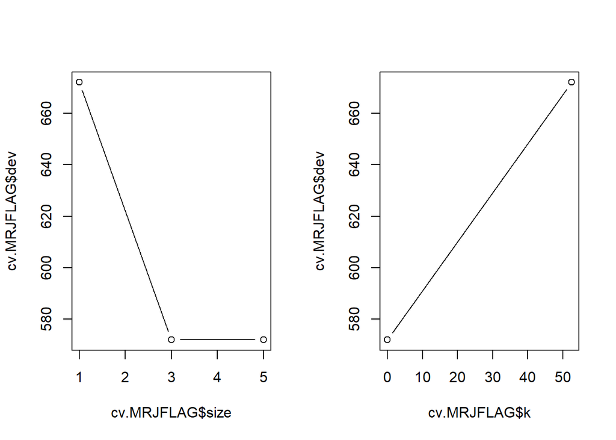

```r
par(mfrow = c(1, 2))
plot(cv.MRJFLAG$size, cv.MRJFLAG$dev, type = "b")
plot(cv.MRJFLAG$k, cv.MRJFLAG$dev, type = "b")
```

Let’s clean up the same plot.

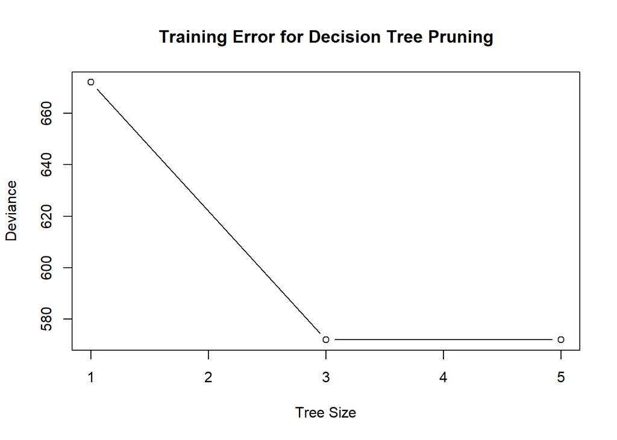

```r
plot(cv.MRJFLAG$size, cv.MRJFLAG$dev, type = "b", xlab = "Tree Size", ylab = "Deviance", main = "Training Error for Decision Tree Pruning")
```

Let’s locate an elbow point. It looks like a tree of size 3 is enough. Let’s determine why.

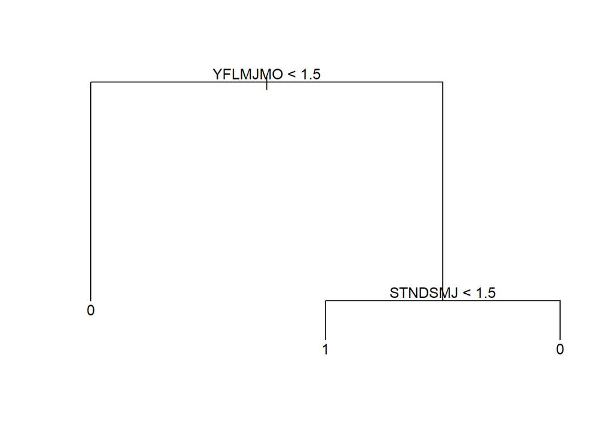

```r
prune.MRJFLAG <- prune.misclass(tree.MRJFLAG, best = 3)
plot(prune.MRJFLAG)
text(prune.MRJFLAG, pretty = 0)
```

Our two variables are YFLMJMO (how youth feels about peers using marijuana monthly) and STNDSMJ (how many students in the youth’s grade smoke marijuana. Here, we see that the youth is vulnerable to a wide host of factors. This follows in our general theme of investigating how social factors affect youth drug use.

Let’s test our accuracy.

```r
pred<-predict(prune.MRJFLAG, test, type="class")

table(pred, test$MRJFLAG)
```

```
##
## pred    0    1
##    0 4261  428
##    1  224  368
```

```r
(224+428)/(sum(table(pred, test$MRJFLAG)))
```

```
## [1] 0.1234615
```

We have about an 87 percent accuracy rate, which is pretty good but not any better from our process of pre-pruning. What this tells us is that our tree might not have really been pruned. Let’s start with our social variables and proceed forward with a slightly more diverse tree.

Since we are following the trend of social factors, let’s use TCHGJOB (whether or not a teacher has told the student they did a good job), STNDSMJ (whether or not grademates use marijuana), PRGDJOB2 (parents tell youth they did a good job), PRPROUD2 (parents tell youth they are proud), FRDMEVR2 (what youths think of close friends smoking more than 1 pack a day), PRTALK3 (youth talked to parent about alcohol, tobacco, and drugs), PRBSOLV2 (youth participated in a self esteem group), PRVDRGO2 (participated in a substance prevention program), GRPCNSL2 (participated in a program to help with substance use), DRPRVME3 (youth sees drug prevention messaging outside school), ANYEDUC3 (youth had drug education in school), and YFLMJMO (what the youth thinks of peers using marijuana monthly).

Before we start, let’s create a new data frame to apply transformations to the data.

```r
youth_data_binary<-youth_data

youth_data_binary$MRJFLAG<-as.factor(youth_data_binary$MRJFLAG)
youth_data_binary$TCHGJOB<-as.factor(youth_data_binary$TCHGJOB)
youth_data_binary$STNDSMJ<-as.factor(youth_data_binary$STNDSMJ)
youth_data_binary$PRGDJOB2<-as.factor(youth_data_binary$PRGDJOB2)
youth_data_binary$PRPROUD2<-as.factor(youth_data_binary$PRPROUD2)
youth_data_binary$FRDMEVR2<-as.factor(youth_data_binary$FRDMEVR2)
youth_data_binary$PRTALK3<-as.factor(youth_data_binary$PRBSOLV2)
youth_data_binary$PRVDRGO2<-as.factor(youth_data_binary$PRVDRGO2)
youth_data_binary$GRPCNSL2<-as.factor(youth_data_binary$GRPCNSL2)
youth_data_binary$DRPRVME3<-as.factor(youth_data_binary$DRPRVME3)
youth_data_binary$ANYEDUC3<-as.factor(youth_data_binary$ANYEDUC3)
youth_data_binary$YFLMJMO<-as.factor(youth_data_binary$YFLMJMO)
```

Let’s try recreating our basic tree.

```r
samp<-sample(1:nrow(youth_data_binary),nrow(youth_data_binary)/2)

train<-youth_data_binary[samp,]

test<-youth_data_binary[-samp,]
```

```r
tree.MRJFLAG_binary<-tree(factor(MRJFLAG)~TCHGJOB+STNDSMJ + PRGDJOB2 + PRPROUD2 + FRDMEVR2 + PRTALK3 + PRBSOLV2 + PRVDRGO2 + GRPCNSL2 + DRPRVME3 + ANYEDUC3 + YFLMJMO, train)

summary(tree.MRJFLAG_binary)
```

```
##
## Classification tree:
## tree(formula = factor(MRJFLAG) ~ TCHGJOB + STNDSMJ + PRGDJOB2 +
##     PRPROUD2 + FRDMEVR2 + PRTALK3 + PRBSOLV2 + PRVDRGO2 + GRPCNSL2 +
##     DRPRVME3 + ANYEDUC3 + YFLMJMO, data = train)
## Variables actually used in tree construction:
## [1] "FRDMEVR2" "STNDSMJ"
## Number of terminal nodes:  4
## Residual mean deviance:  0.6486 = 3118 / 4808
## Misclassification error rate: 0.1361 = 655 / 4812
```

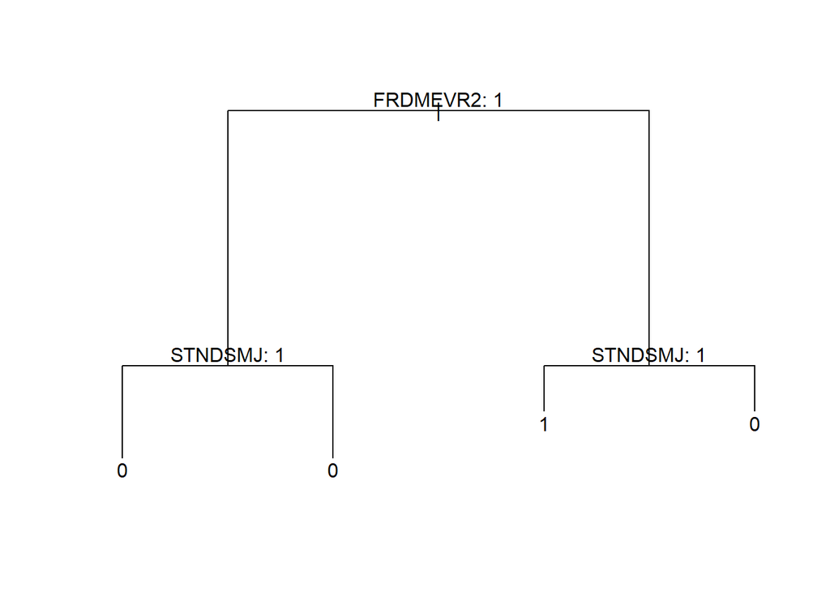

```r
plot(tree.MRJFLAG_binary)
text(tree.MRJFLAG_binary, pretty = 0)
```

```r
pred<-predict(tree.MRJFLAG_binary, test, type="class")

table(pred, test$MRJFLAG)
```

```
##
## pred    0    1
##    0 4240  404
##    1  265  372
```

```r
(247+422)/sum(table(pred, test$MRJFLAG))
```

```
## [1] 0.1266806
```

Surprisingly, our test error rate is even lower than our training error rate.

Let’s see if we can use random forest, varying mtry, to see if we can involve the other variables. Let’s clean the data once more to remove NA values, since random forest does not allow that.

```r
youth_data_RF<-na.omit(youth_data_binary)
```

```r
samp<-sample(1:nrow(youth_data_RF),nrow(youth_data_RF)/2)

train<-youth_data_RF[samp,]

test<-youth_data_RF[-samp,]
```

```r
tree.MRJFLAG_RF<-randomForest(MRJFLAG~ TCHGJOB+STNDSMJ + PRGDJOB2 + PRPROUD2 + FRDMEVR2 + PRTALK3 + PRBSOLV2 + PRVDRGO2 + GRPCNSL2 + DRPRVME3 + ANYEDUC3 + YFLMJMO, data=train, mtry=6, importance=TRUE, ntree=500)
```

```r
print(tree.MRJFLAG_RF)
```

```
##
## Call:
##  randomForest(formula = MRJFLAG ~ TCHGJOB + STNDSMJ + PRGDJOB2 +      PRPROUD2 + FRDMEVR2 + PRTALK3 + PRBSOLV2 + PRVDRGO2 + GRPCNSL2 +      DRPRVME3 + ANYEDUC3 + YFLMJMO, data = train, mtry = 6, importance = TRUE,      ntree = 500)
##                Type of random forest: classification
##                      Number of trees: 500
## No. of variables tried at each split: 6
##
##         OOB estimate of  error rate: 14.63%
## Confusion matrix:
##      0   1 class.error
## 0 3277 181  0.05234239
## 1  424 253  0.62629247
```

Let’s double check our test error.

```r
pred<-predict(tree.MRJFLAG_RF, test, type="class")

table(pred, test$MRJFLAG)
```

```
##
## pred    0    1
##    0 3304  387
##    1  168  277
```

```r
(186+374)/(sum(table(pred,test$MRJFLAG)))
```

```
## [1] 0.1353965
```

We can still try to fine-tune our parameters, however, by making use of the mtry variable.

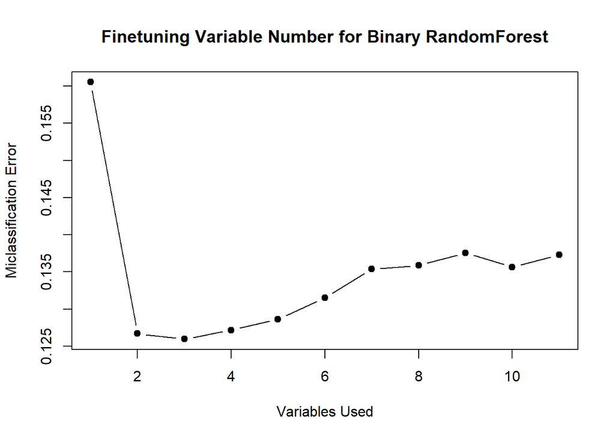

```r
trees<-numeric(11)
errors<-numeric(11)
for (i in 1:11){

tree.MRJFLAG_RF<-randomForest(MRJFLAG~ TCHGJOB+STNDSMJ + PRGDJOB2 + PRPROUD2 + FRDMEVR2 + PRTALK3 + PRBSOLV2 + PRVDRGO2 + GRPCNSL2 + DRPRVME3 + ANYEDUC3 + YFLMJMO, data=train, mtry=i, importance=TRUE, ntree=500)
pred<-predict(tree.MRJFLAG_RF, test, type="class")
trees[i]<-i
errors[i]<-1-sum(diag(table(pred,test$MRJFLAG)))/sum(table(pred,test$MRJFLAG))
}
plot(x=trees, y=errors,type="b",pch=19, xlab = "Variables Used", ylab = "Miclassification Error", main = "Finetuning Variable Number for Binary RandomForest")
```

Let’s consider boosting to try to solve our problem. Recall that boosting can adjust to fit errors more effectively, therefore lowering bias. Let’s try it.

I noticed that GBM requires a numeric response variable, so I convert it back.

```r
train$MRJFLAG <- as.numeric(as.character(train$MRJFLAG))
test$MRJFLAG <- as.numeric(as.character(test$MRJFLAG))
```

```r
boost.MRJFLAG <- gbm(MRJFLAG ~ TCHGJOB+STNDSMJ + PRGDJOB2 + PRPROUD2 + FRDMEVR2 + PRTALK3 + PRBSOLV2 + PRVDRGO2 + GRPCNSL2 + DRPRVME3 + ANYEDUC3 + YFLMJMO, data = train, distribution = "bernoulli", n.trees = 1000, shrinkage=0.011)
pred<-predict(boost.MRJFLAG, test, type="response")
```

```
## Using 1000 trees...
```

```r
pred_class <- ifelse(pred > 0.5, 1, 0)
table(pred_class, test$MRJFLAG)
```

```
##
## pred_class    0    1
##          0 3333  380
##          1  139  284
```

```r
(156+357)/sum(table(pred_class,test$MRJFLAG))
```

```
## [1] 0.1240329
```

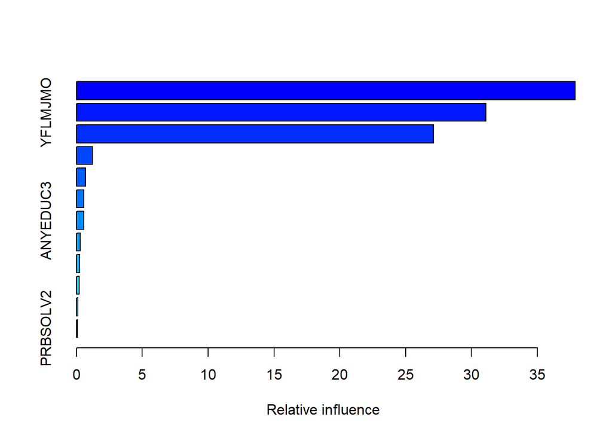

|  | var | rel.inf |
| --- | --- | --- |
| STNDSMJ | STNDSMJ | 37.87784184 |
| YFLMJMO | YFLMJMO | 31.08560993 |
| FRDMEVR2 | FRDMEVR2 | 27.12061486 |
| PRPROUD2 | PRPROUD2 | 1.20915658 |
| GRPCNSL2 | GRPCNSL2 | 0.69021512 |
| PRGDJOB2 | PRGDJOB2 | 0.55940702 |
| ANYEDUC3 | ANYEDUC3 | 0.54450699 |
| DRPRVME3 | DRPRVME3 | 0.29181422 |
| TCHGJOB | TCHGJOB | 0.23309423 |
| PRVDRGO2 | PRVDRGO2 | 0.22526623 |

[output cut: 2 more lines]

```r
summary(boost.MRJFLAG)
```

We were able to decrease our error to about 12.4 percent. This barely beats out our simple tree by a small percentage. However, we have found out that boosting deals with bias much more effectively than random forest.

Let’s try to fine-tune our shrinkage parameter to better improve our results.

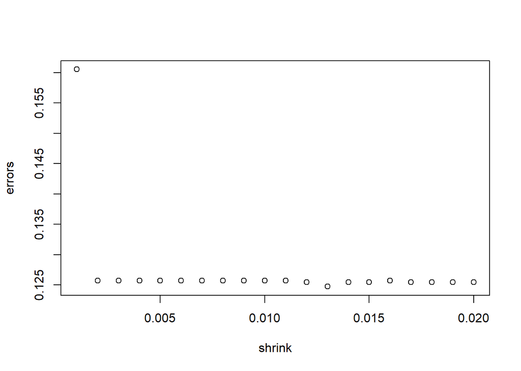

```r
shrink <- numeric(20)
errors <- numeric(20)

for (i in 1:20) {
  boost.MRJFLAG <- gbm(MRJFLAG ~ TCHGJOB + STNDSMJ + PRGDJOB2 + PRPROUD2 + FRDMEVR2 + PRTALK3 + PRBSOLV2 + PRVDRGO2 + GRPCNSL2 + DRPRVME3 + ANYEDUC3 + YFLMJMO,data = train, distribution = "bernoulli",n.trees = 1000,shrinkage = i * 0.001,
  )

  shrink[i] <- i * 0.001
  pred_prob <- predict(boost.MRJFLAG, newdata = test, n.trees = 1000, type = "response")
  pred_class <- ifelse(pred_prob > 0.5, 1, 0)
  error_rate <- 1 - sum(diag(table(pred_class, test$MRJFLAG))) / sum(table(pred_class, test$MRJFLAG))
  errors[i] <- error_rate
}

plot(shrink, errors)
```

```r
boost.MRJFLAG <- gbm(MRJFLAG ~ TCHGJOB+STNDSMJ + PRGDJOB2 + PRPROUD2 + FRDMEVR2 + PRTALK3 + PRBSOLV2 + PRVDRGO2 + GRPCNSL2 + DRPRVME3 + ANYEDUC3 + YFLMJMO, data = train, distribution = "bernoulli", n.trees = 1000, shrinkage=0.006)
pred<-predict(boost.MRJFLAG, test, type="response")
```

```
## Using 1000 trees...
```

```r
pred_class <- ifelse(pred > 0.5, 1, 0)
table(pred_class, test$MRJFLAG)
```

```
##
## pred_class    0    1
##          0 3335  383
##          1  137  281
```

```r
(135+373)/sum(table(pred_class,test$MRJFLAG))
```

```
## [1] 0.122824
```

Let’s now try some multi-class classification problems.

To do this, let’s create a new classification by using IRMJAGE for our cases, which is namely the youth’s first age doing marijuana. Let’s create a multiclassification problem and split age into several buckets.

```r
youth_data_used<-youth_data[youth_data$IRMJAGE<990,]
```

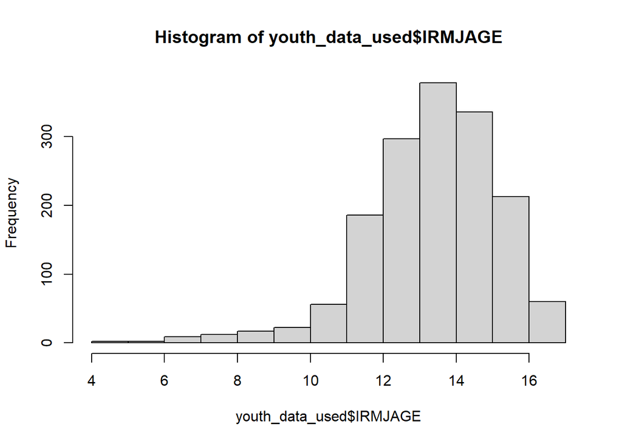

```r
hist(youth_data_used$IRMJAGE)
```

```r
youth_data_used$mrj_age_group <- cut(
  youth_data_used$IRMJAGE,
  breaks = c(-Inf, 12, 13, 14, 15, Inf),
  labels = c("child", "12-13", "13-14", "14-15", "16+"),
  right = TRUE
)
```

We can now use multi classification on this.

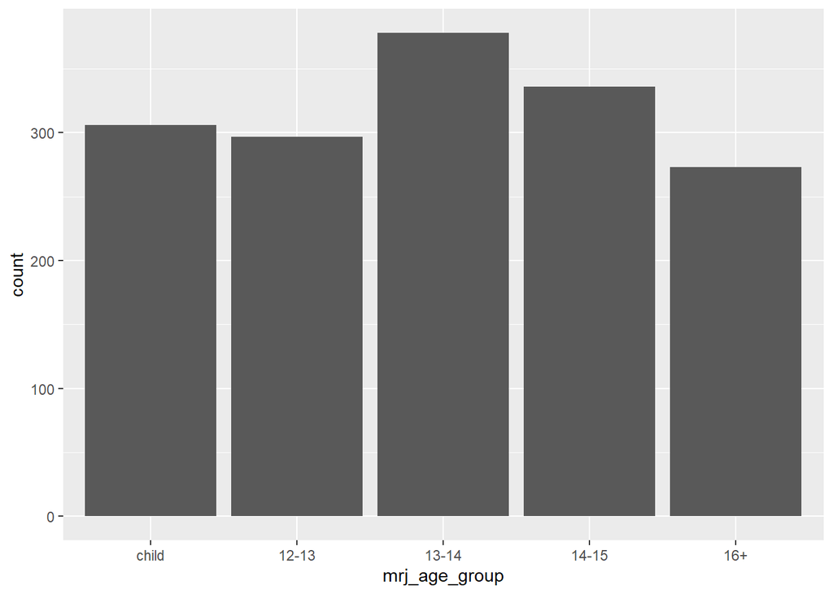

```r
ggplot(youth_data_used, aes(x = mrj_age_group)) + geom_bar()
```

However, we might benefit from comparing our group to those who did not take marijuana either.

```r
youth_data$mrj_age_group <- cut(
  youth_data$IRMJAGE,
  breaks = c(-Inf, 12,13, 14, 15, 19,  Inf),
  labels = c("child","12-13", "13-14", "14-15", "16-18", "never"),
  right = TRUE
)
```

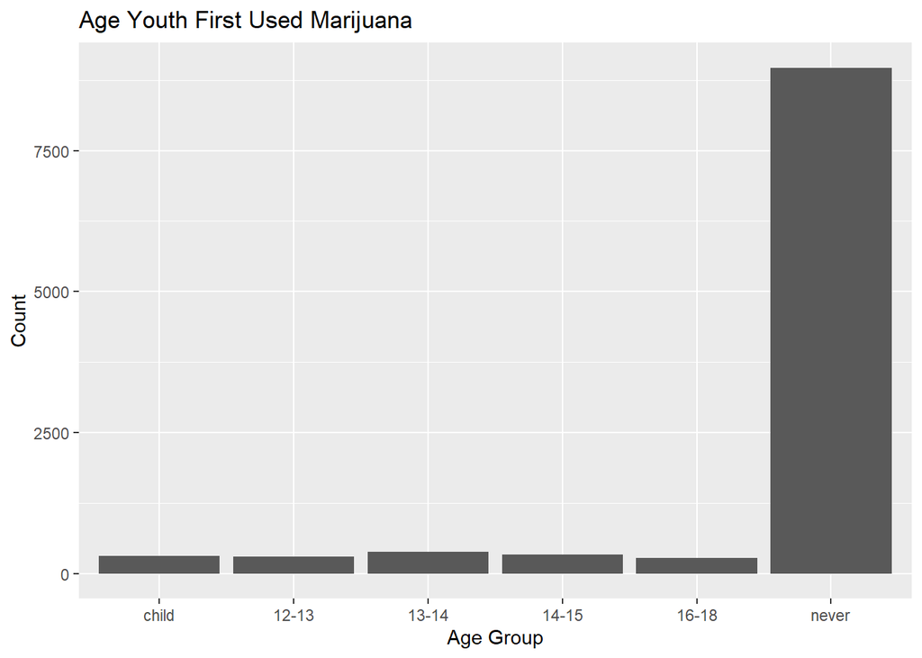

```r
ggplot(youth_data, aes(x = mrj_age_group)) + geom_bar()+
  labs(title = "Age Youth First Used Marijuana", x = "Age Group", y = "Count")
```

For now, let’s perform the classification on the dataset that is more full.

Given the focus on social influence, let’s see what friends and family have to say about when youths start using marijuana.

Let’s determine which categories to use. We want to see which social factors lead to when a youth will start using marijuana.

Let’s split the data.

```r
youth_data_forest<-na.omit(youth_data)
```

Now, let’s properly convert the data into factor form.

```r
youth_data_forest$mrj_age_group<-as.factor(youth_data_forest$mrj_age_group)
youth_data_forest$TCHGJOB<-as.factor(youth_data_forest$TCHGJOB)
youth_data_forest$STNDSMJ<-as.factor(youth_data_forest$STNDSMJ)
youth_data_forest$PRGDJOB2<-as.factor(youth_data_forest$PRGDJOB2)
youth_data_forest$PRPROUD2<-as.factor(youth_data_forest$PRPROUD2)
youth_data_forest$FRDMEVR2<-as.factor(youth_data_forest$FRDMEVR2)
youth_data_forest$PRTALK3<-as.factor(youth_data_forest$PRBSOLV2)
youth_data_forest$PRVDRGO2<-as.factor(youth_data_forest$PRVDRGO2)
youth_data_forest$GRPCNSL2<-as.factor(youth_data_forest$GRPCNSL2)
youth_data_forest$DRPRVME3<-as.factor(youth_data_forest$DRPRVME3)
youth_data_forest$ANYEDUC3<-as.factor(youth_data_forest$ANYEDUC3)
```

```r
samp<-sample(1:nrow(youth_data_forest),nrow(youth_data_forest)/2)

train<-youth_data_forest[samp,]

test<-youth_data_forest[-samp,]
```

Now, we must clean the data. We realize that the random forest function does not allow NA values. Therefore, we need to remove all NA values.

```r
bag.mrj_age_group<-randomForest(mrj_age_group~ TCHGJOB+STNDSMJ + PRGDJOB2 + PRPROUD2 + FRDMEVR2 + PRTALK3 + PRBSOLV2 + PRVDRGO2 + GRPCNSL2 + DRPRVME3 + ANYEDUC3, data=train, mtry=11, importance=TRUE)


bag.mrj_age_group
```

```
##
## Call:
##  randomForest(formula = mrj_age_group ~ TCHGJOB + STNDSMJ + PRGDJOB2 +      PRPROUD2 + FRDMEVR2 + PRTALK3 + PRBSOLV2 + PRVDRGO2 + GRPCNSL2 +      DRPRVME3 + ANYEDUC3, data = train, mtry = 11, importance = TRUE)
##                Type of random forest: classification
##                      Number of trees: 500
## No. of variables tried at each split: 11
##
##         OOB estimate of  error rate: 18.23%
## Confusion matrix:
##       child 12-13 13-14 14-15 16-18 never class.error
## child     8     5     5     2     3   113  0.94117647
## 12-13    10     1     5     2     2   116  0.99264706
## 13-14     5     3     0     1     1   148  1.00000000
## 14-15     8     2     1     1     0   131  0.99300699
## 16-18     3     1     2     1     3   102  0.97321429
## never    24    16    22     8    10  3359  0.02326258
```

As we realize, our model is pretty bad at classifying. Because of how many “never” results there were, we notice that our model spend too much effort prioritizing “never” results at the cost of the other results. Let’s re-do this but with a population that has already tried marijuana.

```r
youth_data_forest<-na.omit(youth_data_used)
```

Now, let’s properly convert the data into factor form.

```r
youth_data_forest$mrj_age_group<-as.factor(youth_data_forest$mrj_age_group)
youth_data_forest$TCHGJOB<-as.factor(youth_data_forest$TCHGJOB)
youth_data_forest$STNDSMJ<-as.factor(youth_data_forest$STNDSMJ)
youth_data_forest$PRGDJOB2<-as.factor(youth_data_forest$PRGDJOB2)
youth_data_forest$PRPROUD2<-as.factor(youth_data_forest$PRPROUD2)
youth_data_forest$FRDMEVR2<-as.factor(youth_data_forest$FRDMEVR2)
youth_data_forest$PRTALK3<-as.factor(youth_data_forest$PRBSOLV2)
youth_data_forest$PRVDRGO2<-as.factor(youth_data_forest$PRVDRGO2)
youth_data_forest$GRPCNSL2<-as.factor(youth_data_forest$GRPCNSL2)
youth_data_forest$DRPRVME3<-as.factor(youth_data_forest$DRPRVME3)
youth_data_forest$ANYEDUC3<-as.factor(youth_data_forest$ANYEDUC3)
#We will use poverty level later, but I include it here for convenience.
youth_data_forest$POVERTY3<-ordered(youth_data_forest$POVERTY3)
```

```r
samp<-sample(1:nrow(youth_data_forest),nrow(youth_data_forest)/2)

train<-youth_data_forest[samp,]

test<-youth_data_forest[-samp,]
```

Now, we must clean the data. We realize that the random forest function does not allow NA values. Therefore, we need to remove all NA values.

```r
bag.mrj_age_group<-randomForest(mrj_age_group~ TCHGJOB+STNDSMJ + PRGDJOB2 + PRPROUD2 + FRDMEVR2 + PRTALK3 + PRBSOLV2 + PRVDRGO2 + GRPCNSL2 + DRPRVME3 + ANYEDUC3, data=train, mtry=11, importance=TRUE)


bag.mrj_age_group
```

```
##
## Call:
##  randomForest(formula = mrj_age_group ~ TCHGJOB + STNDSMJ + PRGDJOB2 +      PRPROUD2 + FRDMEVR2 + PRTALK3 + PRBSOLV2 + PRVDRGO2 + GRPCNSL2 +      DRPRVME3 + ANYEDUC3, data = train, mtry = 11, importance = TRUE)
##                Type of random forest: classification
##                      Number of trees: 500
## No. of variables tried at each split: 11
##
##         OOB estimate of  error rate: 79.82%
## Confusion matrix:
##       child 12-13 13-14 14-15 16+ class.error
## child    26    20    34    29  18   0.7952756
## 12-13    28    21    30    27  22   0.8359375
## 13-14    38    19    34    23  36   0.7733333
## 14-15    37    27    21    37  24   0.7465753
## 16+      19    17    39    26  17   0.8559322
```

Our model is pretty bad. This may be because we don’t have many numerical variables.

We will expect our test error to be even worse.

```r
pred<-predict(bag.mrj_age_group, test, type="class")
table(test$mrj_age_group, pred)
```

```
##        pred
##         child 12-13 13-14 14-15 16+
##   child    35    17    15    24  39
##   12-13    36    20    21    19  29
##   13-14    34    28    18    31  50
##   14-15    36    27    18    22  39
##   16+      28    12    18    22  32
```

```r
x<-sum(table(test$mrj_age_group, pred))

(40+16+41+17+26)/x
```

```
## [1] 0.2089552
```

We only have a 20 percent test accuracy. This is even worse. Our model is about as good as random guessing.

Let’s first try to add more variables.

Let’s use include poverty level (POVERTY3). Perhaps higher poverty may impact the ability of when someone starts using marijuana, either by making the situation more desperate or by allowing more access to marijuana.

```r
youth_data_forest$POVERTY3<-as.factor(youth_data_forest$POVERTY3)
```

Let’s transform when the youth first uses smokeless tobacco and alcohol.

```r
youth_data_used$s_tobac_age <- cut(
  youth_data_used$IRSMKLSSTRY,
  breaks = c(-Inf, 12, 13, 14, 15, Inf),
  labels = c("child", "12-13", "13-14", "14-15", "16+"),
  right = TRUE
)


youth_data_used$alcohol_age <- cut(
  youth_data_used$IRALCAGE,
  breaks = c(-Inf, 12, 13, 14, 15, Inf),
  labels = c("child", "12-13", "13-14", "14-15", "16+"),
  right = TRUE
)
```

Let’s also order our categorical variables and re-make our youth_data_random_forest set.

```r
youth_data_forest<-na.omit(youth_data_used)
youth_data_forest$s_tobac_age<-ordered(youth_data_forest$s_tobac_age)
youth_data_forest$alcohol_age<-ordered(youth_data_forest$alcohol_age)

#Let's also split the data.

samp<-sample(1:nrow(youth_data_forest),nrow(youth_data_forest)/2)

train<-youth_data_forest[samp,]

test<-youth_data_forest[-samp,]
```

```r
bag.mrj_age_group<-randomForest(mrj_age_group~ TCHGJOB+STNDSMJ + PRGDJOB2 + PRPROUD2 + FRDMEVR2 + PRTALK3 + PRBSOLV2 + PRVDRGO2 + GRPCNSL2 + DRPRVME3 + ANYEDUC3+POVERTY3+s_tobac_age+alcohol_age, data=train, mtry=11, importance=TRUE)


bag.mrj_age_group
```

```
##
## Call:
##  randomForest(formula = mrj_age_group ~ TCHGJOB + STNDSMJ + PRGDJOB2 +      PRPROUD2 + FRDMEVR2 + PRTALK3 + PRBSOLV2 + PRVDRGO2 + GRPCNSL2 +      DRPRVME3 + ANYEDUC3 + POVERTY3 + s_tobac_age + alcohol_age,      data = train, mtry = 11, importance = TRUE)
##                Type of random forest: classification
##                      Number of trees: 500
## No. of variables tried at each split: 11
##
##         OOB estimate of  error rate: 73.39%
## Confusion matrix:
##       child 12-13 13-14 14-15 16+ class.error
## child    44    32    25    11   8   0.6333333
## 12-13    30    24    29    24  20   0.8110236
## 13-14    25    27    30    31  35   0.7972973
## 14-15    12    29    34    35  32   0.7535211
## 16+       7    16    26    38  45   0.6590909
```

```r
pred<-predict(bag.mrj_age_group, test, type="class")
sum(diag(table(pred, test$mrj_age_group)))/sum(table(pred,test$mrj_age_group))
```

```
## [1] 0.2850746
```

It seems that adding the the multi-level variables increases our accuracy by 10 percent. Let’s compare it with a standard tree with the multi-level variables.

```r
tree.mrj_age_group<-tree(mrj_age_group ~ POVERTY3+s_tobac_age+alcohol_age, data=train)

summary(tree.mrj_age_group)
```

```
##
## Classification tree:
## tree(formula = mrj_age_group ~ POVERTY3 + s_tobac_age + alcohol_age,
##     data = train)
## Variables actually used in tree construction:
## [1] "alcohol_age"
## Number of terminal nodes:  3
## Residual mean deviance:  2.99 = 1992 / 666
## Misclassification error rate: 0.6756 = 452 / 669
```

```r
pred<-predict(tree.mrj_age_group, test, type="class")
sum(diag(table(pred, test$mrj_age_group)))/sum(table(pred,test$mrj_age_group))
```

```
## [1] 0.280597
```

Our success rate is 30 percent.

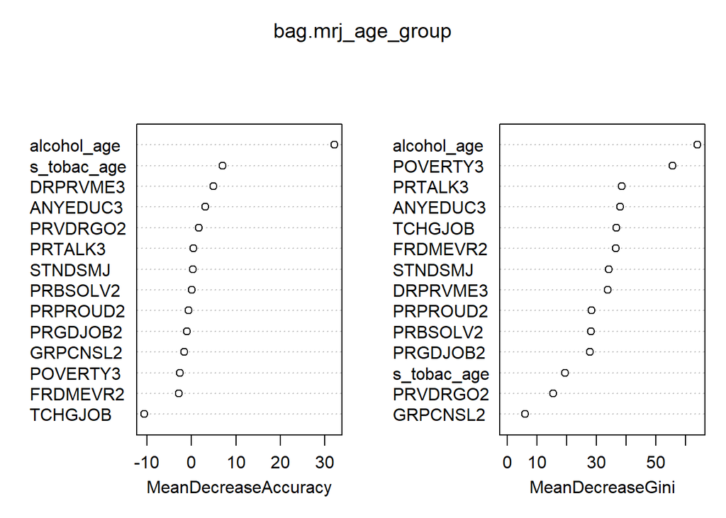

```r
varImpPlot(bag.mrj_age_group)
```

SECTION 3

Let’s see if we can use regression to determine how many days a year that a youth would use marijuana. Let’s start first by analyzing social factors around them and then seeing what we can predict.

To do this, let’s clean the marijuana frequency for the past year, because IRMJFY has two values 991 and 993, which indicate never using marijuana and not using marijuana the past year respectively. Let’s see how large each is.

```r
table(youth_data$IRMJFY)
```

```
##
##    1    2    3    4    5    6    7    8    9   10   11   12   13   14   15   16
##  121   81   65   43   44   27   15   18   10   31    5   44    6    5   14    5
##   17   18   19   20   21   22   23   24   25   27   28   29   30   31   32   33
##    5    7    3   13    6    7    3   57    6    6    3    3   11    2    3    4
##   34   35   36   37   38   40   41   42   43   45   46   47   48   50   51   52
##    5    7   34    3    3    4    1    2    1    3    3    3   27    6    3   46
##   53   54   56   57   58   60   63   67   68   69   70   72   78   80   81   83
##    1    1    1    1    1   24    1    1    3    2    1    9    1    1    1    1
##   84   85   86   90   93   96   97   98   99  100  102  103  104  105  108  110
##    9    1    1    1    2   12    1    2    1    4    1    1   45    2    4    3
##  112  120  127  128  130  133  134  135  136  139  142  144  147  150  154  155
##    1   17    1    3    1    1    1    1    1    1    1    9    1    3    1    2
##  156  168  179  180  184  198  200  204  206  208  214  218  228  230  240  250
##   40    4    1   16    1    1    1    3    1   50    1    1    1    1   14    2
##  252  260  261  264  288  300  309  312  320  336  338  340  342  345  348  350
##    1   58    2    1    1    4    1   29    1    1    1    1    4    1    1    1
##  353  355  358  360  361  362  363  364  365  991  993
##    2    5    1    4    1    2    6   50    9 8971  255
```

We notice 8971 entries in the “never” tried marijuna category. For worry that the data becomes too unbalanced, let’s exclude entries with 991 and set 993 to 0, which makes sense since that indicates no marijuana the past year.

```r
youth_data_mrj_freq<- youth_data[youth_data$IRMJFY != 991, ]

youth_data_mrj_freq$IRMJFY<-ifelse(youth_data_mrj_freq$IRMJFY==993, 0, youth_data_mrj_freq$IRMJFY)
```

Now we can remove all rows with an NA value in IRMJFY, since we would have nothing to predict.

```r
youth_data_mrj_freq<-subset(youth_data_mrj_freq, !is.na(IRMJFY))
```

We notice here that we have much less data, only 1590.

```r
str(youth_data_mrj_freq)
```

```
## 'data.frame':    1590 obs. of  80 variables:
##  $ IRALCFY      : int  991 991 991 5 993 13 3 991 991 12 ...
##  $ IRMJFY       : num  60 10 168 364 240 8 10 36 2 150 ...
##  $ IRCIGFM      : num  91 20 91 93 91 91 93 91 91 93 ...
##  $ IRSMKLSS30N  : int  91 91 91 93 91 91 91 91 91 91 ...
##  $ IRALCFM      : num  91 91 91 93 93 93 2 91 91 93 ...
##  $ IRMJFM       : num  2 5 14 30 10 93 5 1 2 93 ...
##  $ IRCIGAGE     : int  991 17 991 14 991 991 16 991 991 16 ...
##  $ IRSMKLSSTRY  : int  991 991 991 14 991 991 991 991 991 991 ...
##  $ IRALCAGE     : int  991 991 991 13 13 14 17 991 991 14 ...
##  $ IRMJAGE      : int  14 17 14 13 13 14 15 15 15 15 ...
##  $ MRJFLAG      : Factor w/ 2 levels "0","1": 2 2 2 2 2 2 2 2 2 2 ...
##  $ ALCFLAG      : int  0 0 0 1 1 1 1 0 0 1 ...
##  $ TOBFLAG      : int  0 1 0 1 0 1 1 0 0 1 ...
##  $ ALCYDAYS     : int  6 6 6 1 6 2 1 6 6 2 ...
```

[output cut: 66 more lines]

Let’s start with the listed social factors and add on a few more numeric variables.

```r
youth_data_mrj_freq$TCHGJOB<-as.factor(youth_data_mrj_freq$TCHGJOB)
youth_data_mrj_freq$STNDSMJ<-as.factor(youth_data_mrj_freq$STNDSMJ)
youth_data_mrj_freq$PRGDJOB2<-as.factor(youth_data_mrj_freq$PRGDJOB2)
youth_data_mrj_freq$PRPROUD2<-as.factor(youth_data_mrj_freq$PRPROUD2)
youth_data_mrj_freq$FRDMEVR2<-as.factor(youth_data_mrj_freq$FRDMEVR2)
youth_data_mrj_freq$PRTALK3<-as.factor(youth_data_mrj_freq$PRBSOLV2)
youth_data_mrj_freq$PRVDRGO2<-as.factor(youth_data_mrj_freq$PRVDRGO2)
youth_data_mrj_freq$GRPCNSL2<-as.factor(youth_data_mrj_freq$GRPCNSL2)
youth_data_mrj_freq$DRPRVME3<-as.factor(youth_data_mrj_freq$DRPRVME3)
youth_data_mrj_freq$ANYEDUC3<-as.factor(youth_data_mrj_freq$ANYEDUC3)
youth_data_mrj_freq$POVERTY3<-as.factor(youth_data_mrj_freq$POVERTY3)
```

However, let’s also use alcohol frequency. But to do so, let’s make the same transformations.

Normally, we would remove 991, but we can instead treat 991 as 0 days used alcohol because unbalanced data is no longer a worry when it comes to a predictor variable (it would be negative)

```r
youth_data_mrj_freq$IRALCFY<-ifelse(youth_data_mrj_freq$IRALCFY==991, 0, youth_data_mrj_freq$IRALCFY)

youth_data_mrj_freq$IRALCFY<-ifelse(youth_data_mrj_freq$IRALCFY==993, 0, youth_data_mrj_freq$IRALCFY)
```

Let’s also try comparing it with monthly smokeless tobacco frequency (IRSMKLSS30N), monthly cigar frequency (IRCIGFM).

```r
youth_data_mrj_freq$IRSMKLSS30N<-ifelse(youth_data_mrj_freq$IRSMKLSS30N==91, 0, youth_data_mrj_freq$IRSMKLSS30N)
youth_data_mrj_freq$IRSMKLSS30N<-ifelse(youth_data_mrj_freq$IRSMKLSS30N==93, 0, youth_data_mrj_freq$IRSMKLSS30N)

youth_data_mrj_freq$IRCIGFM<-ifelse(youth_data_mrj_freq$IRCIGFM==91, 0, youth_data_mrj_freq$IRCIGFM)
youth_data_mrj_freq$IRCIGFM<-ifelse(youth_data_mrj_freq$IRCIGFM==93, 0, youth_data_mrj_freq$IRCIGFM)
```

```r
samp<-sample(1:nrow(youth_data_mrj_freq),nrow(youth_data_mrj_freq)/2)

train<-youth_data_mrj_freq[samp,]

test<-youth_data_mrj_freq[-samp,]
```

Let’s now perform a simple regression tree and update it with an advanced technique.

```r
tree.mrj_reg<-tree(IRMJFY~TCHGJOB+STNDSMJ + PRGDJOB2 + PRPROUD2 + FRDMEVR2 + PRTALK3 + PRBSOLV2 + PRVDRGO2 + GRPCNSL2 + DRPRVME3 + ANYEDUC3 + POVERTY3 + IRSMKLSS30N + IRCIGFM +IRALCFY, train )

summary(tree.mrj_reg)
```

```
##
## Regression tree:
## tree(formula = IRMJFY ~ TCHGJOB + STNDSMJ + PRGDJOB2 + PRPROUD2 +
##     FRDMEVR2 + PRTALK3 + PRBSOLV2 + PRVDRGO2 + GRPCNSL2 + DRPRVME3 +
##     ANYEDUC3 + POVERTY3 + IRSMKLSS30N + IRCIGFM + IRALCFY, data = train)
## Variables actually used in tree construction:
## [1] "IRALCFY"  "PRVDRGO2" "FRDMEVR2" "POVERTY3" "ANYEDUC3" "TCHGJOB"
## Number of terminal nodes:  9
## Residual mean deviance:  10410 = 7717000 / 741
## Distribution of residuals:
##    Min. 1st Qu.  Median    Mean 3rd Qu.    Max.
## -202.20  -53.68  -41.60    0.00   25.24  311.30
```

```r
pred<-predict(tree.mrj_reg, newdata=test)
mean((test$IRMJFY-pred)**2)
```

```
## [1] 10006.48
```

This is a pretty large MSE.

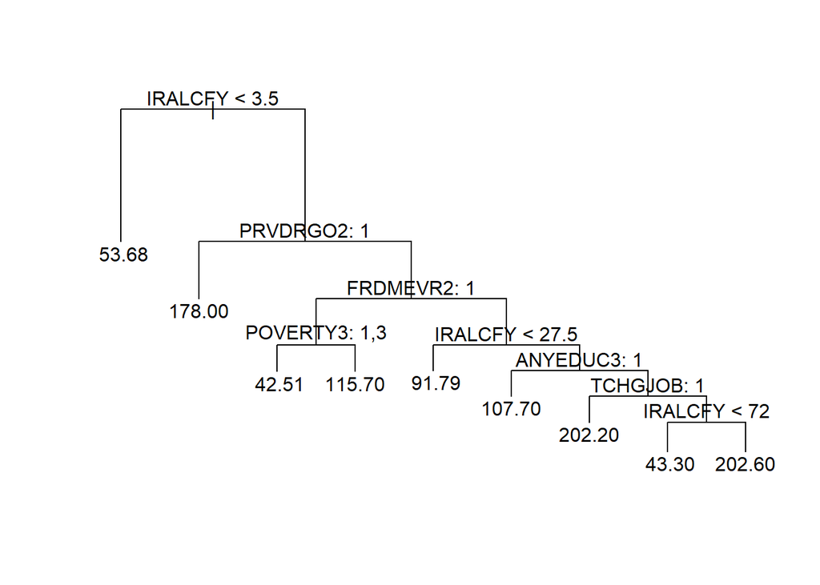

```r
plot(tree.mrj_reg)
text(tree.mrj_reg, pretty = 0)
```

Let’s use boosting to try to improve our results.

```r
set.seed(1)
boost.mrj_reg <- gbm(IRMJFY ~ TCHGJOB+STNDSMJ + PRGDJOB2 + PRPROUD2 + FRDMEVR2 + PRTALK3 + PRBSOLV2 + PRVDRGO2 + GRPCNSL2 + DRPRVME3 + ANYEDUC3 + POVERTY3 + IRSMKLSS30N + IRCIGFM +IRALCFY, data = train,
    distribution = "gaussian", n.trees = 1000)
```

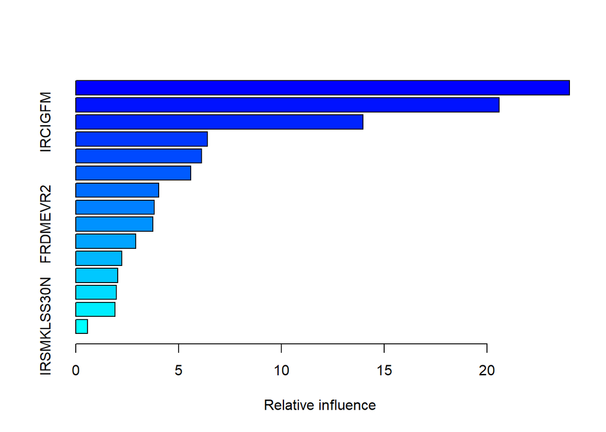

|  | var | rel.inf |
| --- | --- | --- |
| IRALCFY | IRALCFY | 24.0208738 |
| PRVDRGO2 | PRVDRGO2 | 20.6094326 |
| IRCIGFM | IRCIGFM | 13.9662320 |
| TCHGJOB | TCHGJOB | 6.4155244 |
| ANYEDUC3 | ANYEDUC3 | 6.1121312 |
| STNDSMJ | STNDSMJ | 5.5998002 |
| PRTALK3 | PRTALK3 | 4.0471216 |
| POVERTY3 | POVERTY3 | 3.8100943 |
| FRDMEVR2 | FRDMEVR2 | 3.7548657 |
| DRPRVME3 | DRPRVME3 | 2.9142614 |

[output cut: 5 more lines]

```r
summary(boost.mrj_reg)
```

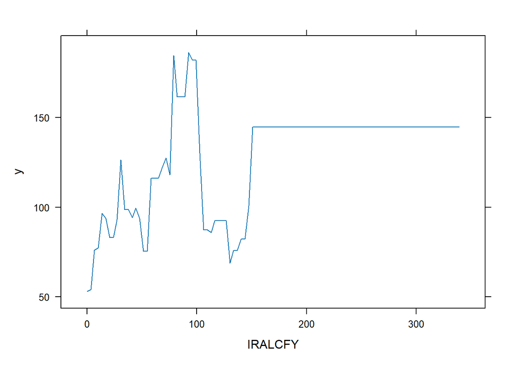

```r
plot(boost.mrj_reg, i = "IRALCFY")
```

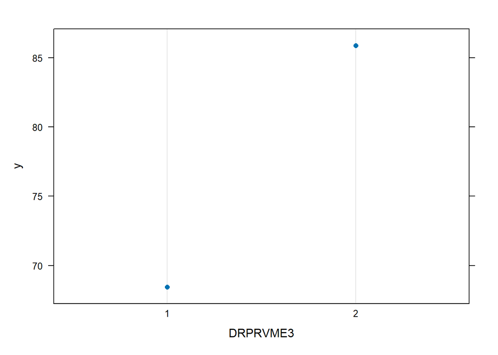

```r
plot(boost.mrj_reg, i = "DRPRVME3")
```

Now let’s check our test MSE after boosting.

```r
pred<-predict(boost.mrj_reg, test)
```

```
## Using 1000 trees...
```

```r
mean((test$IRMJFY-pred)**2)
```

```
## [1] 9613.007
```

Our test MSE is only marginally better. Let’s fine tune our shrinkage parameter here.

```r
shrink<-numeric(20)
errors<-numeric(20)
for (i in 1:20){
boost.mrj_reg <- gbm(IRMJFY ~ TCHGJOB+STNDSMJ + PRGDJOB2 + PRPROUD2 + FRDMEVR2 + PRTALK3 + PRBSOLV2 + PRVDRGO2 + GRPCNSL2 + DRPRVME3 + ANYEDUC3 + POVERTY3 + IRSMKLSS30N + IRCIGFM +IRALCFY, data = train,
    distribution = "gaussian", n.trees = 500, shrinkage=i*0.001)
  shrink[i]<-i*0.001
  test.pred<- predict(boost.mrj_reg, newdata = test, n.trees = 1000)
  test.mse<-mean((test.pred-test$IRMJFY)**2)
  errors[i]<-test.mse
}
```

[output not shown]

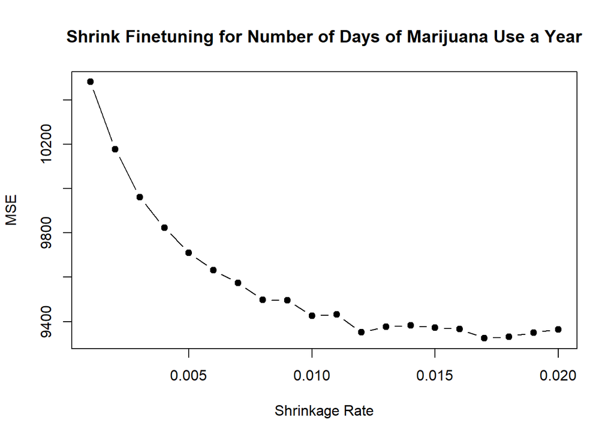

```r
plot(y=errors, x=shrink, xlab = "Shrinkage Rate", pch=19, type="b",
  ylab = "MSE",
  main = "Shrink Finetuning for Number of Days of Marijuana Use a Year")
```

```r
boost.mrj_reg <- gbm(IRMJFY ~ TCHGJOB+STNDSMJ + PRGDJOB2 + PRPROUD2 + FRDMEVR2 + PRTALK3 + PRBSOLV2 + PRVDRGO2 + GRPCNSL2 + DRPRVME3 + ANYEDUC3 + POVERTY3 + IRSMKLSS30N + IRCIGFM +IRALCFY, data = train, distribution = "gaussian", n.trees = 1000, shrinkage=0.011)
test.pred<- predict(boost.mrj_reg, newdata = test, n.trees = 1000)
mean((test.pred-test$IRMJFY)**2)
```

```
## [1] 9331.472
```

We were able to decrease our MSE a little bit more. Let’s reconsider our most useful variables.

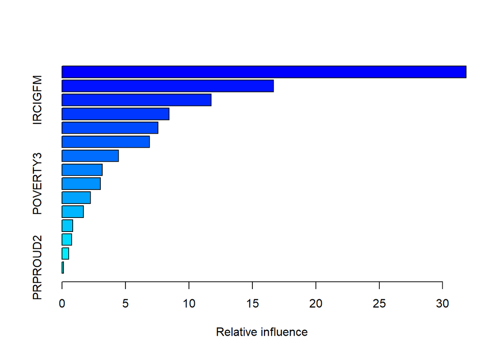

|  | var | rel.inf |
| --- | --- | --- |
| IRALCFY | IRALCFY | 31.8441599 |
| PRVDRGO2 | PRVDRGO2 | 16.6793972 |
| IRCIGFM | IRCIGFM | 11.7401243 |
| FRDMEVR2 | FRDMEVR2 | 8.4486214 |
| STNDSMJ | STNDSMJ | 7.5700218 |
| ANYEDUC3 | ANYEDUC3 | 6.9038283 |
| DRPRVME3 | DRPRVME3 | 4.4482983 |
| PRTALK3 | PRTALK3 | 3.1610818 |
| POVERTY3 | POVERTY3 | 3.0262645 |
| TCHGJOB | TCHGJOB | 2.2360657 |

[output cut: 5 more lines]

```r
summary(boost.mrj_reg)
```